# ncov-recombinant v0.5.1 - v0.6.0

Test Summary Package

*This report was automatically generated on November 7, 2022.*

## Authors

**Katherine Eaton** | National Microbiology Laboratory, PHAC | katherine.eaton@phac-aspc.gc.ca

## 1. Summary

The ncov-recombinant update from `v0.5.1` to `v0.6.0` has two major changes.

The first change is a `Nextclade` upgrade to the [sars-cov-2 2022-10-27 dataset](https://github.com/nextstrain/nextclade_data/releases/tag/2022-10-31--11-48-49--UTC), which introduces recombinant sublineages for the first time (ex. XBB.1) and two new lineages: XBD and XBE.

The second major change is the calculation and visualization of immune-related statistics. In `v0.6.0`, the number of key receptor binding domain (RBD) mutations is calculated for every sample. This is performed by comparing the Nextclade `aaSubstitutions` column (amino acid substitutions) produced by Nextclade, to the list of [12 key RBD mutations](https://github.com/nextstrain/ncov/blob/master/defaults/rbd_levels.yaml) provided by Nextstrain. In addition, the statistics `immune_escape` and `ace2_binding` from Nextclade are included in the final linelists.

Between `v0.5.1` and `v0.6.0`, **14.2%** of sequences in the `controls-gisaid` dataset had different detection results. **4.0%** of sequences were newly classified (`NA` → `X*`) and represent lineages not present in the `v0.5.1` model. **10.2%** of sequences had *sublineage* assignment changes as a result of the `Nextclade` dataset upgrade. **0.0%** of positive controls were dropped (`X*` → `NA`), indicating no observed loss in sensitivity.

`ncov-recombinant` `v0.6.0` is a recommended upgrade for recombinant surveillance to enable sublineage classification and to access enhanced statistics regarding immune-escape.

For a comprehensive summary of the methodological changes, please see the [release notes for v0.6.0](https://github.com/ktmeaton/ncov-recombinant/releases/tag/v0.6.0)

## 2. Purpose

Verify that the update of ncov-recombinant pipeline from version `0.5.1` to`0.6.0`:

1. Maintains specificity for recombinants trained in previous versions.
2. Increases sensitivity for newly designated recombinant sublineages.

## 3. Datasets

### Controls (`controls-gisaid`)

This dataset includes SARS-CoV-2 genomes from GISAID that reflect the known diversity of recombinant sequences to date. These include `501` positive controls (recombinants), representing lineages XA - XBE and `186` negative controls (non-recombinants) selected from the [Nextstrain Reference Phylogeny](https://nextstrain.org/ncov/gisaid/reference).

In total, `687` control sequences were used as input and a [strain list is available here](https://raw.githubusercontent.com/ktmeaton/ncov-recombinant/v0.6.0/data/controls-gisaid/strains.txt).

## 4. Procedure

The snakemake pipelines for `v0.5.1` and `v0.6.0` were run independently on the same dataset (`controls-gisaid`). Please see the Procedure section in the Supplementary for detailed command-line instructions.

## 5. Results

### Controls (`controls-gisaid`)

- **85.8%** (430/501) of lineage assignments were unchanged (Figure 1).
- **4.0%** (20/501) of sequences were newly classified as recombinants.
- **0.0%** (0/501) of sequences changed *lineage* assignments.
- **10.2%** (51/501) of sequences changed *sublineage* assignments (ex. `XBB` → `XBB.1`).
- **0.0%** (0/501) of sequences were dropped as positives (`NA`).

> **Note**: Lineage assignments in `v0.6.0` are identical to those in pango-designation and are the expected values.

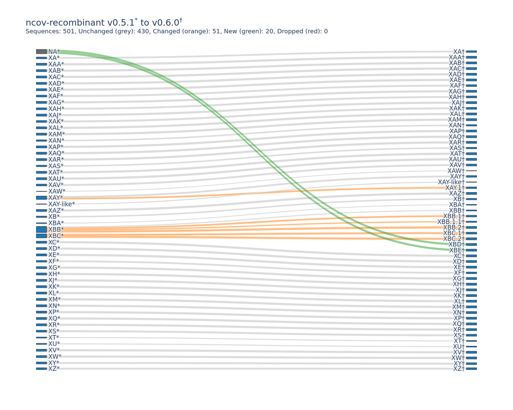

Figure 1: Comparison of lineage assignments in the `controls-gisaid` dataset between `v0.5.1` and `v0.6.0`.

#### New Detections

**New detections** (`NA` → `X*`) result from the following changes in `v0.6.0`:

1. Nextclade dataset upgrades to include newly delegated lineages XBD and XBE.

#### Lineage Changes

**Sublineage changes** result from the following updates in `v0.6.0`:

1. Nextclade dataset upgrades to include XAY.1, XBB.1, XBB.1.1, XBB.2, XBC.1, and XBC.2.

#### Reporting Period Plots

The following plots report recombinant sequences over the last 16 weeks.

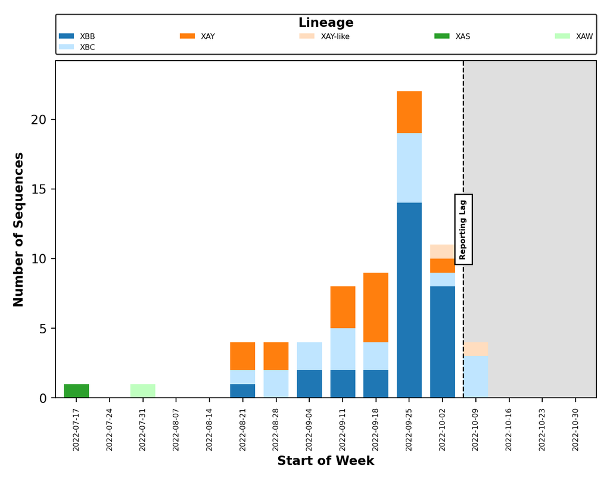

Figure 2: Reporting period timeline of recombinants in the `controls-gisaid` dataset in `v0.5.1`.

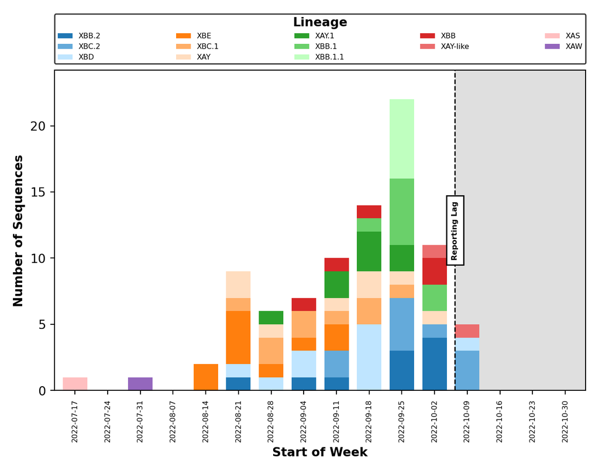

Figure 3: Reporting period timeline of recombinants in the `controls-gisaid` dataset in `v0.6.0`.

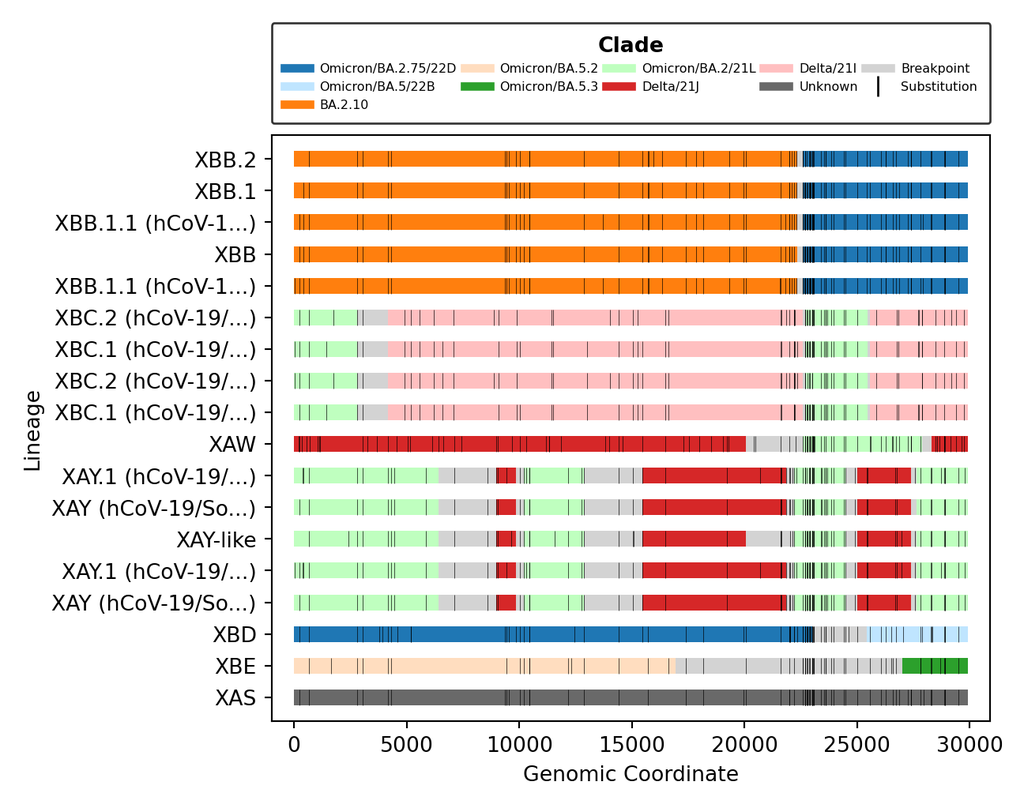

Figure 4: Reporting period breakpoint distributions by clade of the `controls-gisaid` dataset in `v0.6.0`.

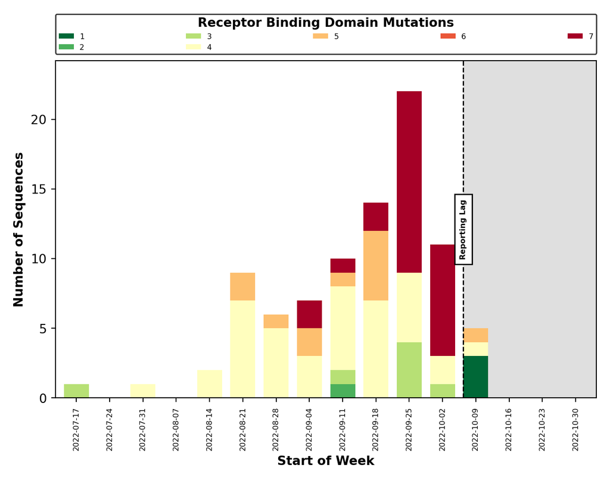

Figure 5: Reporting period timeline of receptor binding domain (RBD) mutations in the `controls-gisaid` dataset in `v0.6.0`.

## Supplementary

> **Note**: Download the GISDAID sequences and metadata in the [strains list](https://raw.githubusercontent.com/ktmeaton/ncov-recombinant/v0.6.0/data/controls-gisaid/strains.txt) to `data/controls-gisaid/`.

### Procedure

#### Version 0.5.1 | 799904eb

1. Download the pipeline.

   ```bash
   git clone https://github.com/ktmeaton/ncov-recombinant.git 0.5.1
   cd 0.5.1
   git checkout v0.5.1
   ```

2. Symlink `controls-gisaid`, data.

   ```bash
   rm -rf data/controls-gisaid
   ln -s ../data/controls-gisaid data/controls-gisaid
   ```

3. Create a version-controlled conda environment.

   ```bash
   # Local
   mamba env create -f workflow/envs/environment.yaml -n ncov-recombinant-0.5.1

   # HPC
   sbatch -J conda-ncov-recombinant-0.5.1 --wrap="mamba env create -f workflow/envs/environment.yaml -n ncov-recombinant-0.5.1"
   ```

4. Run the pipeline.

   ```bash
   # Local
   conda activate ncov-recombinant-0.5.1
   snakemake --profile profiles/controls-gisaid-hpc

   # HPC
   scripts/slurm.sh --profile profiles/controls-gisaid-hpc --conda-env ncov-recombinant-0.5.1
   ```

#### Version 0.6.0 | fae7bfdb

1. Download the pipeline.

   ```bash
   git clone https://github.com/ktmeaton/ncov-recombinant.git 0.5.0
   cd 0.6.0
   git checkout v0.6.0
   ```

2. Symlink `controls-gisaid`, data.

   ```bash
   rm -rf data/controls-gisaid
   ln -s ../data/controls-gisaid data/controls-gisaid
   ```

3. Create a version-controlled conda environment.

   ```bash
   # Local
   mamba env create -f workflow/envs/environment.yaml -n ncov-recombinant-0.6.0

   # HPC
   sbatch -J conda-ncov-recombinant-0.5.1 --wrap="mamba env create -f workflow/envs/environment.yaml -n ncov-recombinant-0.6.0"
   ```

4. Run the pipeline.

   ```bash
   # Local
   conda activate ncov-recombinant-0.6.0
   snakemake --profile profiles/controls-gisaid-hpc

   # HPC
   scripts/slurm.sh --profile profiles/controls-gisaid-hpc --conda-env ncov-recombinant-0.6.0
   ```

### Comparison

After the pipelines are complete for each version, run the following to compare lineage assignments.

```bash
python3 0.6.0/scripts/compare_positives.py \
  --positives-1 0.5.1/results/controls-gisaid/linelists/positives.tsv \
  --positives-2 0.6.0/results/controls-gisaid/linelists/positives.tsv \
  --ver-1 "v0.5.1" \
  --ver-2 "v0.6.0" \
  --outdir compare/controls-gisaid \
  --node-order alphabetical \
  --min-link-size 1
```

#### New Lineages

```bash
csvtk cut -t -f "strain" 0.5.1/results/controls-gisaid/linelists/positives.tsv \
  | tail -n+2 \
  | csvtk grep -t -f "strain" -P - -v 0.6.0/results/controls-gisaid/linelists/positives.tsv \
  | csvtk cut -t -f "strain" \
  | tail -n+2 \
  | csvtk grep -t -f "strain" -P - 0.5.1/results/controls-gisaid/linelists/linelist.tsv \
  | csvtk pretty -t \
  | less -S
```

#### Dropped Lineages

```bash
csvtk cut -t -f "strain" 0.6.0/results/controls-gisaid/linelists/positives.tsv \
  | tail -n+2 \
  | csvtk grep -t -f "strain" -P - -v 0.5.1/results/controls-gisaid/linelists/positives.tsv \
  | csvtk cut -t -f "strain" \
  | tail -n+2 \
  | csvtk grep -t -f "strain" -P - 0.6.0/results/controls-gisaid/linelists/linelist.tsv \
  | csvtk pretty -t \
  | less -S
```

### Historical Plots

The following plots report all recombinant sequences.

#### Controls (`controls-gisaid`)

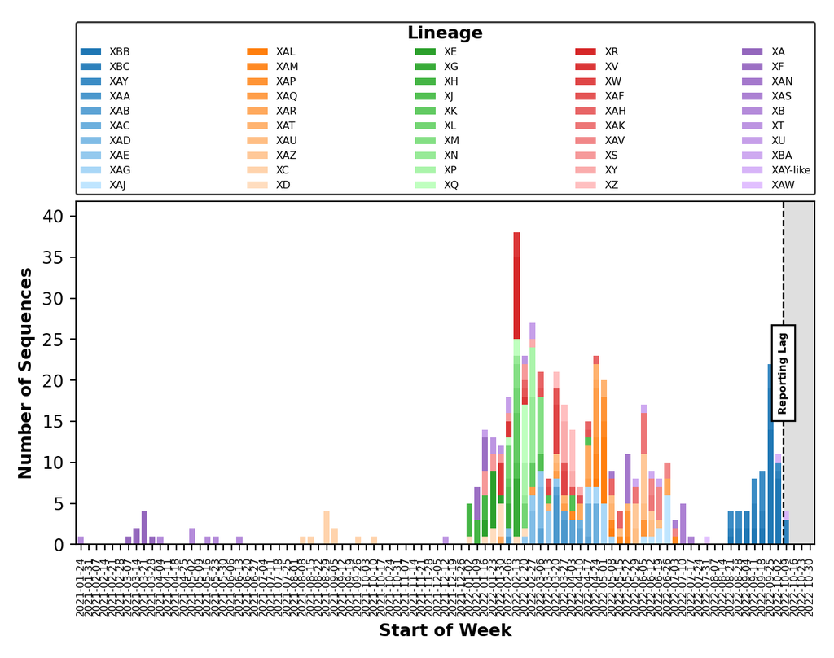

Figure 6: Historical timeline of recombinants in the `controls-gisaid` dataset in `v0.5.1`.

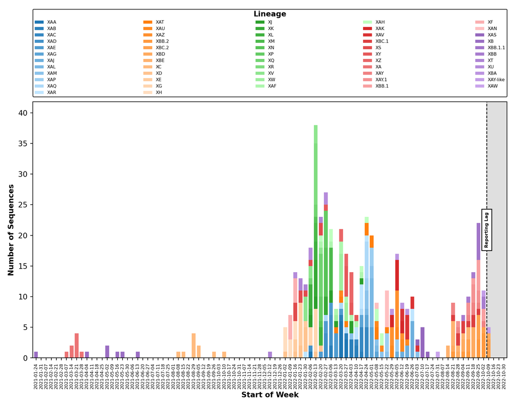

Figure 7: Historical timeline of recombinants in the `controls-gisaid` dataset in `v0.6.0`.

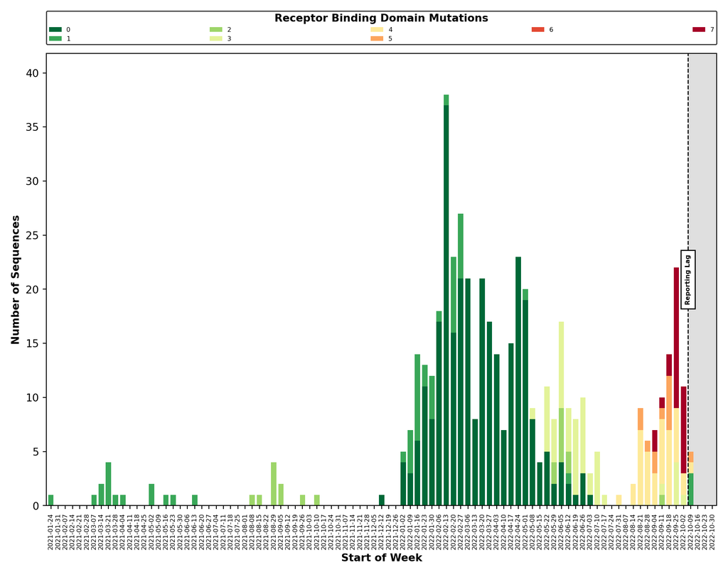

Figure 8: Historical timeline of receptor binding domain (RBD) mutations in the `controls-gisaid` dataset in `v0.6.0`.

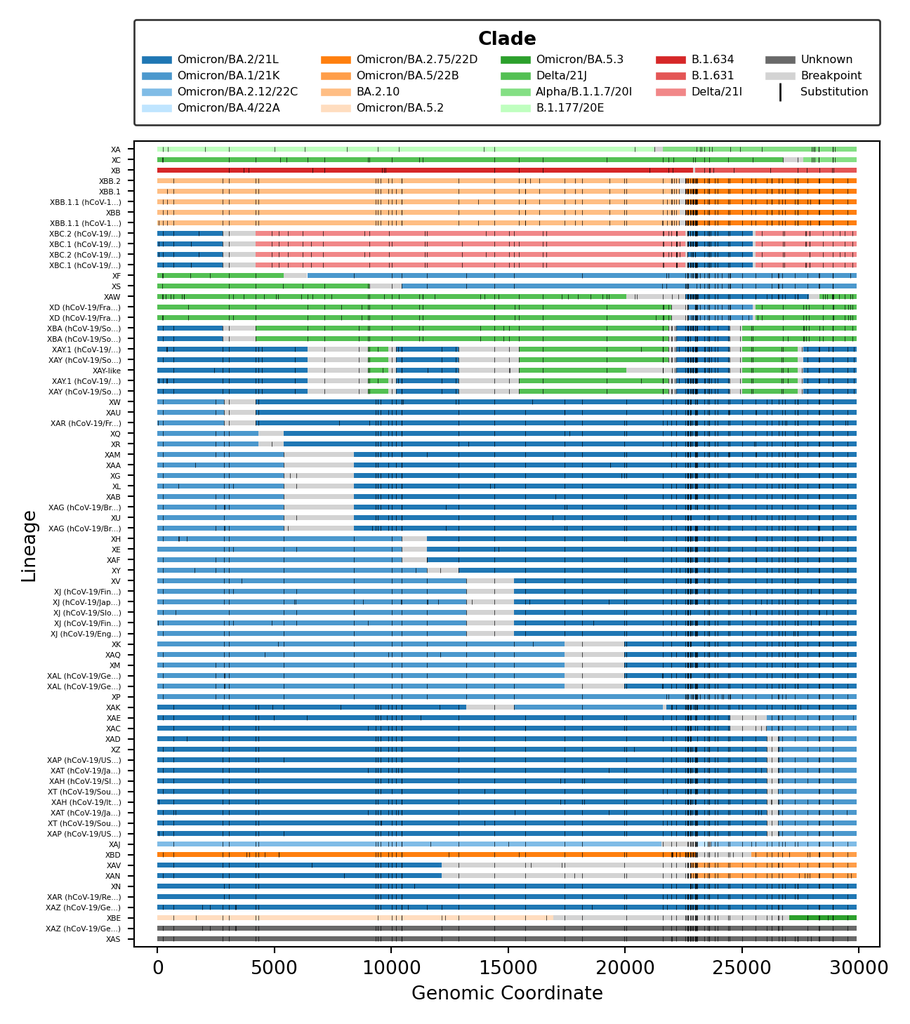

Figure 9: Historical breakpoint distributions by clade of the `controls-gisaid` dataset in `v0.6.0`.